# linear_algebra

Linear algebra is one of the pillars of machine learning. Before dealing further, let us highlight some of the reasons to learn linear algebra for machine learning.

1. Linear Algebra is the absolute key to understanding the calculus and statistics you need in machine learning
2. It will provide greater intuition on how and when the machine learning algorithms work
3. It provides a deeper understanding of the algorithm and its constraints, which will allow you to customize its application and better understand the impact of tuning parameters on the results.
4. Linear algebra helps you to implement the algorithms from scratch and also model and design your own algorithms.

Let us take an example: You want to get married and you are looking forward to meet some girls or boys. Then you want to model a system that finds the most suitable girl or boy for you. What will be your approaches ?

Understand the gemoetric intution behind Linear Algebra

Study Materials: I strongly recommend the following video lecture series

1. Linear Algebra – Gilbert Strang (of the ubiquitous textbook) http://ocw.mit.edu/courses/mathematics/18-06-linear-algebra-spring-2010/
2. Linear Algebra – Foundations to Frontiers https://www.edx.org/course/linear-algebra-foundations-frontiers-utaustinx-ut-5-03x
3. Lecture series - Essence of Linear Algebra from 3Blue1Brown youtube channel https://www.youtube.com/watch?v=kjBOesZCoqc&list=PLZHQObOWTQDPD3MizzM2xVFitgF8hE_ab

### Vectors

1. Physicists viewpoint: Vectors are physical quantities with magnitude and direction, represented by an arrow pointing at any space. The length of the arrow represents the magnitude and the direction it is pointing represents the direction.
2. Computer Scientists viewpoint: Vectors are the ordered list of numbers and can be used to represent any physical quantities. For example, if we want to represent the age of all the participants in a machine learning workshop, we can do so by simply representing as a vector where: $$ \text{age} = \begin{bmatrix} 21 & 23 & 24 & 26 & 32 & 28 & 23 & 25 & 25 & 24\end{bmatrix}$$

If we want to represent a house with area, price, number of bedrooms, number of family living, we can do so as a vector. $$ \text{house} = \begin{bmatrix} 100 & 300000 & 5 & 3 \end{bmatrix}$$

```python
age = [21.0, 23.0, 24.0,26.0, 32.0, 28.0, 23.0, 25.0, 25.0, 24.0]
house = [100.0, 300000.0, 5.0,3.0]

print(type(age))
print(type(house))
```

```
<class 'list'>
<class 'list'>
```

Another way to represent vectors is using numerical python (*numpy* packages). For this we import numpy at first

```python
import numpy as np
age = np.array([21.0, 23.0, 24.0,26.0, 32.0, 28.0, 23.0, 25.0, 25.0, 24.0])
house = np.array([100.0, 300000.0, 5.0,3.0])

print(type(age))
print(type(house))
```

```
<class 'numpy.ndarray'>
<class 'numpy.ndarray'>
```

##### Addition of vectors

```python
a = np.array([2.0,5.0,4.0,14.0])
b = np.array([6.0,3.0,12.0,7.0])

c= a+b

print(c)
print(type(a))
print(type(c))
print(c.size)
```

```
[  8.   8.  16.  21.]
<class 'numpy.ndarray'>
<class 'numpy.ndarray'>
4
```

##### Plotting the Vectors

We use python package called *matplotlib* to plot the figures. Since it is easier to visualize two dimensional figures. Let us first consider two dimensional vectors.

```python
%matplotlib inline
import matplotlib.pyplot as plt

from pylab import rcParams
rcParams['figure.figsize']= 12, 6
rcParams['axes.facecolor']= 'white'
rcParams['axes.edgecolor']= 'blue'

u = np.array([-4.0,2.0])
v = np.array([2.0,3.0])
```

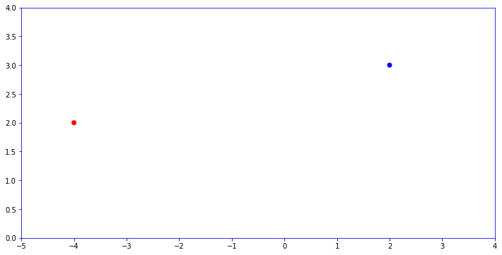

```python
xcords, ycords = zip(u,v)
plt.scatter(xcords,ycords,color=["r","b"]);
plt.axis([-5, 4, 0, 4]);
```

Vectors can be plotted as points in a space. But most of the time vectors are also represented by arrows. Hence, we write a function that plots vectors as an arrow

```python
def plot_vector2d(vector2d, origin=[0, 0], **options):
    return plt.arrow(origin[0], origin[1], vector2d[0], vector2d[1],
              head_width=0.2, head_length=0.3, length_includes_head=True,
              **options)
```

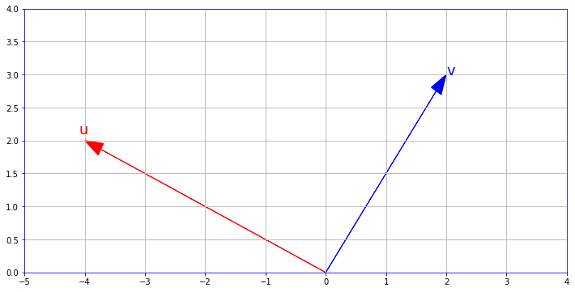

```python
plot_vector2d(u, color="r");
plot_vector2d(v, color="b");
plt.axis([-5, 4, 0, 4]);
plt.text(-4.1, 2.1, "u", color="r", fontsize=18);
plt.text(2.0, 3.0, "v", color="b", fontsize=18);
plt.grid()
```

#### What about 3D vectors ?

Let us first consider two three dimensional vectors as

```python
a = np.array([2.0,1.0,5.0])
b = np.array([5.0,3.0,6.0])
```

We use *mpl_toolkits* python package to plot three dimensional figures.

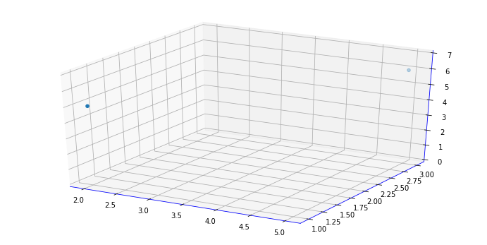

```python
from mpl_toolkits.mplot3d import Axes3D
subplot3d = plt.subplot(111, projection='3d')
x_coords, y_coords, z_coords = zip(a,b)
subplot3d.scatter(x_coords, y_coords, z_coords)
subplot3d.set_zlim3d([0, 7]);
```

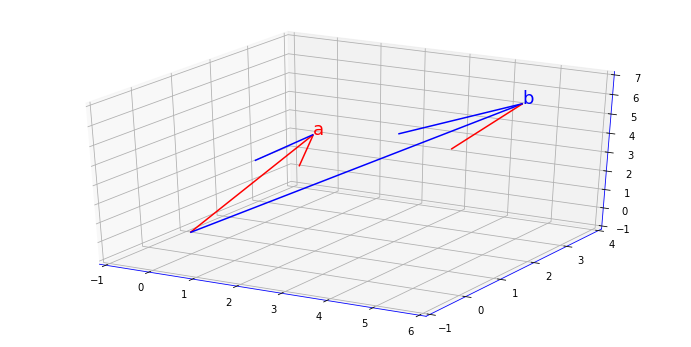

```python
def plot_vectors3d(ax,vectors3d,origin=[0,0,0],**options):
    vectors3d_cons = []
    for i in range(len(vectors3d)):
        acon = np.concatenate((origin,vectors3d[i]))
        vectors3d_cons.append(acon)
    X,Y,Z,U,V,W = zip(*vectors3d_cons)
    return ax.quiver(X, Y, Z, U, V, W, color=("r", "b"))

fig = plt.figure()
ax = fig.add_subplot(111, projection='3d')
plot_vectors3d(ax,[a,b], color=["r","b"])
ax.set_xlim([-1.0, 6.0])
ax.set_ylim([-1.0, 4.0])
ax.set_zlim([-1.0, 7.0])
ax.text(2.0, 1.0,5.0, "a", color="r", fontsize=18);
ax.text(5.0, 3.0,6.0, "b", color="b", fontsize=18);
```

#### Norm of a Vector

The norm of a vector $\textbf{u}$, noted $\left \Vert \textbf{u} \right \|$, is a measure of the length or magnitude of vector $\textbf{u}$. There are multiple possible norms, but the most common one is the Euclidian norm, which is defined as:

$\left \Vert \textbf{u} \right \| = \sqrt{\sum_{i}{\textbf{u}_i}^2}$

```python
def vector_norm(vector):
    squares = [element**2 for element in vector]
    return sum(squares)**0.5

print("||", u, "|| ={}".format(vector_norm(u)))
```

```
|| [-4.  2.] || =4.47213595499958
```

But it is convenient to use the `norm` function available in numpy available in `linalg` module as:

```python
import numpy.linalg as LA
LA.norm(u)
```

```
4.4721359549995796
```

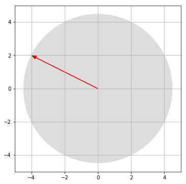

```python
radius = LA.norm(u)
circle= plt.Circle((0,0), radius, color="#DDDDDD")
fig, ax = plt.subplots()
ax.add_artist(circle)
ax.set_aspect('equal')
plot_vector2d(u, color="red")
plt.axis([-5, 5, -5, 5])
plt.grid()
```

#### Scalar Multiplication of Vectors

Scaling of vector length in given direction. The scaling factors are scalars. For example, if we have vector $\mathbf{u}$, sclaed with some scalars $k=2$, the new vector length is twice that of previous one.

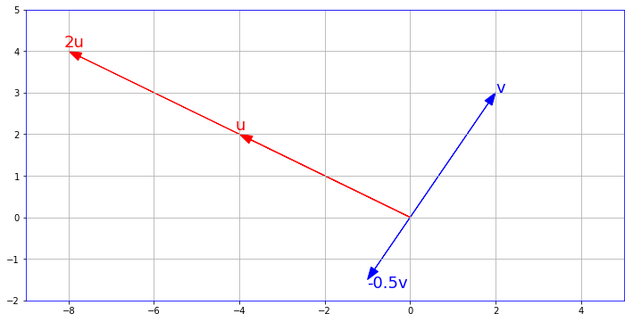

```python
plot_vector2d(u, color="r");
plot_vector2d(2*u, color="r");
plot_vector2d(v, color="b");
plot_vector2d(-0.5*v, color="b");
plt.axis([-9, 5, -2, 5]);
plt.grid()
plt.text(-4.1, 2.1, "u", color="r", fontsize=18);
plt.text(-8.1, 4.1, "2u", color="r", fontsize=18);
plt.text(2, 3, "v", color="b", fontsize=18);
plt.text(-1, -1.7, "-0.5v", color="b", fontsize=18);
```

#### Unit Vector

A vector of unit length (length =1) is called a unit vector. It is often denoted by lowercase letters with a hat, such as $\hat{i}, \hat{j}, \hat{k}$ etc. A normalized vector of any non-zero vector $\mathbf{u}$ is the unit vector in the direction of $\mathbf{u}$, expressed as: $$\hat{\mathbf{u}} = \frac{\mathbf{u}}{|\mathbf{u}|} $$

In 2D coordinate system, we represent unit vector in the direction of x-axis and y-axis by $\hat{i}$ and $\hat{j}$ respectively. Thus, any vector can be represented as the sum of two vectors in the direction of $\hat{i}$ and $\hat{j}$ scaled by some scalars $x$ and $y$ as: $$ \begin{bmatrix} 2 \\ 3 \end{bmatrix} = 2\hat{i} + 3\hat{j}$$

##### Why are unit vectors important ?

Unit vectors are chosen as the **basis** for the **vector space**. For example $\hat{i}$ and $\hat{j}$ are the basis of 2D vector space in x-y coordinate systems. It is not necessary that the basis should always be $\hat{i}$ and $\hat{j}$ but **Basis** for any vector space $\mathcal{V}$ is a vector or set of vectors which are linearly independent and every vector in the vector space is the linear combination of the set.

**Linear combination** for any set of vectors $\{\mathbf{v_1},\mathbf{v_2},\cdots, \mathbf{v_n}\}$ and any set of scalars $\{\alpha_1, \alpha_2, \cdots, \alpha_n\}$ is defined as the sum: $$ \alpha_1\mathbf{v_1} + \alpha_2\mathbf{v_2} + \cdots + \alpha_n\mathbf{v_n} $$

For the given basis, the region spanned by all the possible scalers is called the **span** of the vector space.

```python
print(" ", u)
print("+", v)
print("-"*10)
u + v
```

```
  [-4.  2.]
+ [ 2.  3.]
----------
```

```
array([-2.,  5.])
```

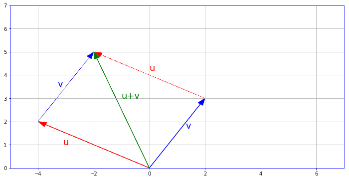

```python
plot_vector2d(u, color="r")
plot_vector2d(v, color="b")
plot_vector2d(v, origin=u, color="b", linestyle="dotted")
plot_vector2d(u, origin=v, color="r", linestyle="dotted")
plot_vector2d(u+v, color="g")
plt.axis([-5, 7, 0, 7])
plt.text(-3.1, 1, "u", color="r", fontsize=18)
plt.text(0, 4.2, "u", color="r", fontsize=18)
plt.text(1.3, 1.7, "v", color="b", fontsize=18)
plt.text(-3.3, 3.5, "v", color="b", fontsize=18)
plt.text(-1, 3, "u+v", color="g", fontsize=18)
plt.grid()
```

### Matrices

One of the ways to express matrices is to write them as a list of lists.

```python
A = [[1,2,3],[4,5,6]]
B = [[3,4,5],[7,9,2]]

print("A={}".format(A))
print("B={}".format(B))

print("C1={}".format(A+B))
print("C={}".format(np.add(A,B)))
```

```
A=[[1, 2, 3], [4, 5, 6]]
B=[[3, 4, 5], [7, 9, 2]]
C1=[[1, 2, 3], [4, 5, 6], [3, 4, 5], [7, 9, 2]]
C=[[ 4  6  8]
 [11 14  8]]
```

Like in vectors, we can use numpy library to express matrices.

```python
A = np.array([[1,2,3],[4,5,6]])
B = np.array([[3,4,5],[7,9,2]])

print("A={}".format(A))
print("B={}".format(B))

print("C={}".format(A+B))
```

```
A=[[1 2 3]
 [4 5 6]]
B=[[3 4 5]
 [7 9 2]]
C=[[ 4  6  8]
 [11 14  8]]
```

```python
print(A.shape)
print(B.shape)
```

```
(2, 3)
(2, 3)
```

```python
#Transpose of a matrix
print("A^T={}".format(A.T))
```

```
A^T=[[1 4]
 [2 5]
 [3 6]]
```

#### Converting 1D array to 2D array

```python
u
```

```
array([-4.,  2.])
```

```python
u.T
```

```
array([-4.,  2.])
```

```python
u_row = np.array([u])
u_row
```

```
array([[-4.,  2.]])
```

```python
u_row = u[np.newaxis,:]
u_row
```

```
array([[-4.,  2.]])
```

```python
u_row = u[np.newaxis]
u_row
```

```
array([[-4.,  2.]])
```

```python
u_row = u[None]
u_row
```

```
array([[-4.,  2.]])
```

```python
u_row.T
```

```
array([[-4.],
       [ 2.]])
```

```python
u[:,np.newaxis]
```

```
array([[-4.],
       [ 2.]])
```

### Plotting matrices

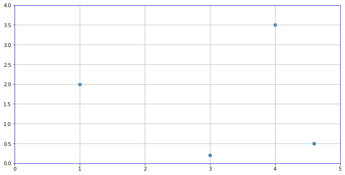

```python
P = np.array([
        [3.0, 4.0, 1.0, 4.6],
        [0.2, 3.5, 2.0, 0.5]
    ])
x_coords_P, y_coords_P = P
plt.scatter(x_coords_P, y_coords_P)
plt.axis([0, 5, 0, 4]);
plt.grid()
```

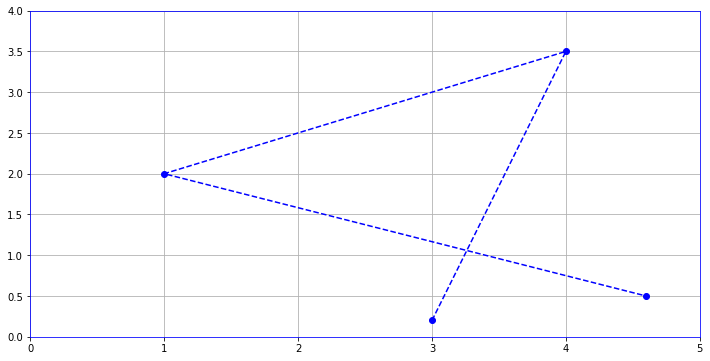

```python
plt.plot(x_coords_P, y_coords_P, "bo")
plt.plot(x_coords_P, y_coords_P, "b--")
plt.axis([0, 5, 0, 4]);
plt.grid()
```

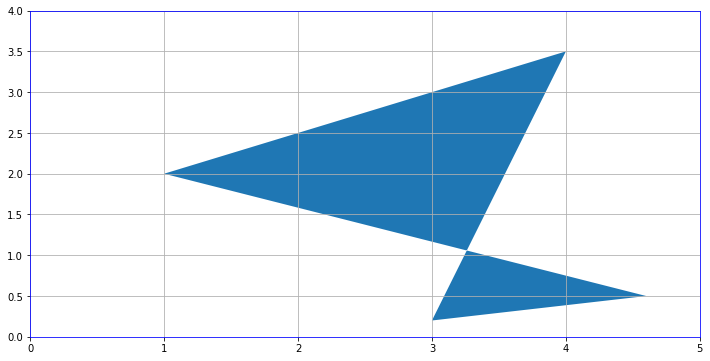

```python
from matplotlib.patches import Polygon
plt.gca().add_artist(Polygon(P.T))
plt.axis([0, 5, 0, 4]);
plt.grid()
```

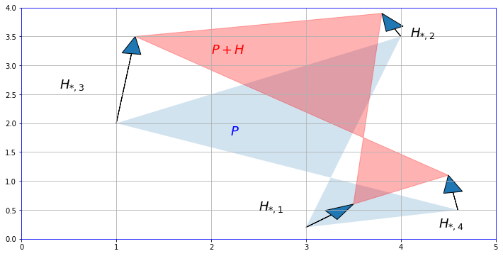

```python
H = np.array([
        [ 0.5, -0.2, 0.2, -0.1],
        [ 0.4,  0.4, 1.5, 0.6]
    ])
P_moved = P + H

plt.gca().add_artist(Polygon(P.T, alpha=0.2))
plt.gca().add_artist(Polygon(P_moved.T, alpha=0.3, color="r"))
for vector, origin in zip(H.T, P.T):
    plot_vector2d(vector, origin=origin)

plt.text(2.2, 1.8, "$P$", color="b", fontsize=18)
plt.text(2.0, 3.2, "$P+H$", color="r", fontsize=18)
plt.text(2.5, 0.5, "$H_{*,1}$", color="k", fontsize=18)
plt.text(4.1, 3.5, "$H_{*,2}$", color="k", fontsize=18)
plt.text(0.4, 2.6, "$H_{*,3}$", color="k", fontsize=18)
plt.text(4.4, 0.2, "$H_{*,4}$", color="k", fontsize=18)

plt.axis([0, 5, 0, 4]);
plt.grid()
```

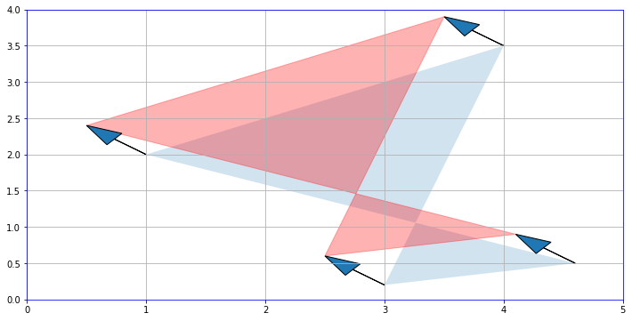

```python
H2 = np.array([
        [-0.5, -0.5, -0.5, -0.5],
        [ 0.4,  0.4,  0.4,  0.4]
    ])
P_translated = P + H2

plt.gca().add_artist(Polygon(P.T, alpha=0.2))
plt.gca().add_artist(Polygon(P_translated.T, alpha=0.3, color="r"))
for vector, origin in zip(H2.T, P.T):
    plot_vector2d(vector, origin=origin)

plt.axis([0, 5, 0, 4]);
plt.grid()
```

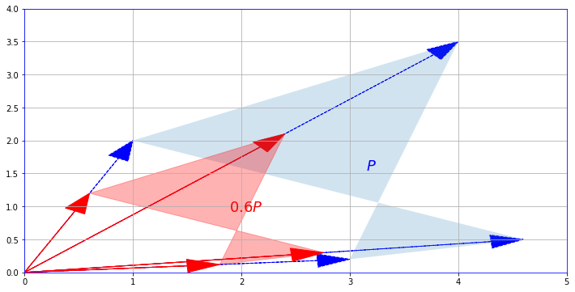

```python
def plot_transformation(P_before, P_after, text_before, text_after, axis = [0, 5, 0, 4], arrows=False):
    if arrows:
        for vector_before, vector_after in zip(P_before.T, P_after.T):
            plot_vector2d(vector_before, color="blue", linestyle="--")
            plot_vector2d(vector_after, color="red", linestyle="-")
    plt.gca().add_artist(Polygon(P_before.T, alpha=0.2))
    plt.gca().add_artist(Polygon(P_after.T, alpha=0.3, color="r"))
    plt.text(P_before[0].mean(), P_before[1].mean(), text_before, fontsize=18, color="blue")
    plt.text(P_after[0].mean(), P_after[1].mean(), text_after, fontsize=18, color="red")
    plt.axis(axis)
    plt.grid()

P_rescaled = 0.60 * P
plot_transformation(P, P_rescaled, "$P$", "$0.6 P$", arrows=True)
```

```python
U = np.array([[1, 0]])
U.dot(P)
```

```
array([[ 3. ,  4. ,  1. ,  4.6]])
```

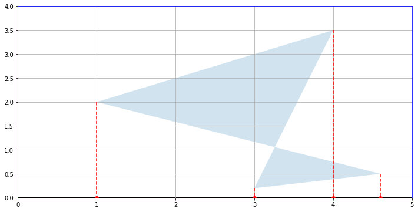

```python
def plot_projection(U, P):
    U_P = U.dot(P)

    axis_end = 100 * U
    plot_vector2d(axis_end[0], color="black")

    plt.gca().add_artist(Polygon(P.T, alpha=0.2))
    for vector, proj_coordinate in zip(P.T, U_P.T):
        proj_point = proj_coordinate * U
        plt.plot(proj_point[0][0], proj_point[0][1], "ro")
        plt.plot([vector[0], proj_point[0][0]], [vector[1], proj_point[0][1]], "r--")

    plt.axis([0, 5, 0, 4])
    plt.grid()
    plt.show()

plot_projection(U, P)
```

We can actually project on any other axis by just replacing $U$ with any other unit vector. For example, let's project on the axis that is at a 30° angle above the horizontal axis:

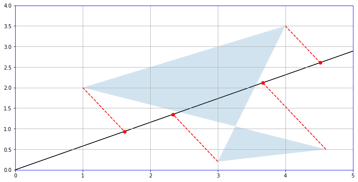

```python
angle30 = 30 * np.pi / 180  # angle in radians
U_30 = np.array([[np.cos(angle30), np.sin(angle30)]])

plot_projection(U_30, P)
```

#### Matrix multiplication – Rotation

Now let's create a $2 \times 2$ matrix $V$ containing two unit vectors that make 30° and 120° angles with the horizontal axis:

$V = \begin{bmatrix} \cos(30°) & \sin(30°) \\ \cos(120°) & \sin(120°) \end{bmatrix}$

```python
angle120 = 120 * np.pi / 180
V = np.array([
        [np.cos(angle30), np.sin(angle30)],
        [np.cos(angle120), np.sin(angle120)]
    ])
V
```

```
array([[ 0.8660254,  0.5      ],
       [-0.5      ,  0.8660254]])
```

```python
V.dot(P)
```

```
array([[ 2.69807621,  5.21410162,  1.8660254 ,  4.23371686],
       [-1.32679492,  1.03108891,  1.23205081, -1.8669873 ]])
```

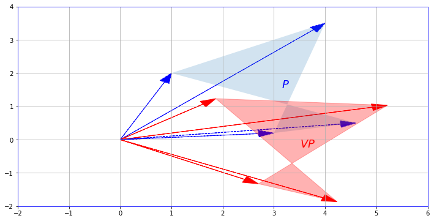

```python
P_rotated = V.dot(P)
plot_transformation(P, P_rotated, "$P$", "$VP$", [-2, 6, -2, 4], arrows=True)
```

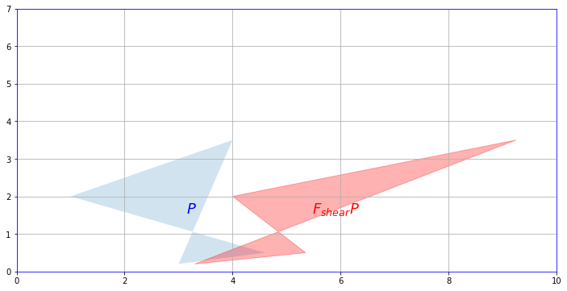

```python
F_shear = np.array([
        [1, 1.5],
        [0, 1]
    ])
plot_transformation(P, F_shear.dot(P), "$P$", "$F_{shear} P$",
                    axis=[0, 10, 0, 7])
```

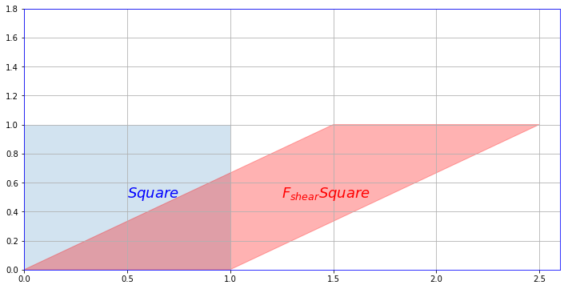

```python
Square = np.array([
        [0, 0, 1, 1],
        [0, 1, 1, 0]
    ])
plot_transformation(Square, F_shear.dot(Square), "$Square$", "$F_{shear} Square$",
                    axis=[0, 2.6, 0, 1.8])
```

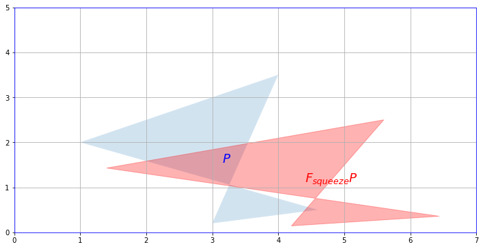

```python
F_squeeze = np.array([
        [1.4, 0],
        [0, 1/1.4]
    ])
plot_transformation(P, F_squeeze.dot(P), "$P$", "$F_{squeeze} P$",
                    axis=[0, 7, 0, 5])
```

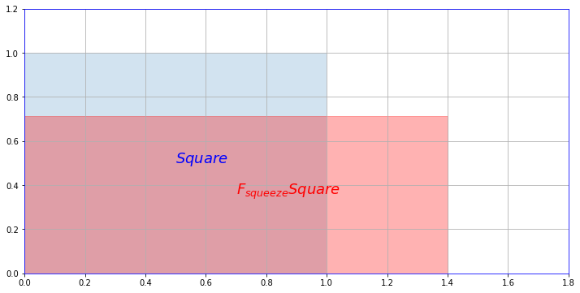

```python
plot_transformation(Square, F_squeeze.dot(Square), "$Square$", "$F_{squeeze} Square$",
                    axis=[0, 1.8, 0, 1.2])
```

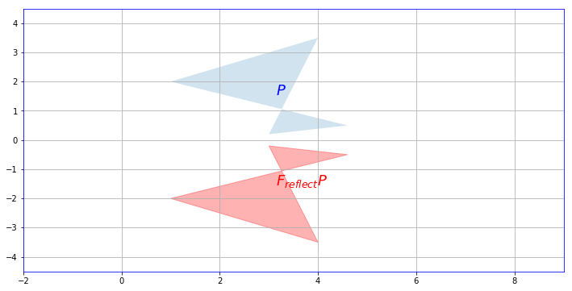

```python
F_reflect = np.array([
        [1, 0],
        [0, -1]
    ])
plot_transformation(P, F_reflect.dot(P), "$P$", "$F_{reflect} P$",
                    axis=[-2, 9, -4.5, 4.5])
```

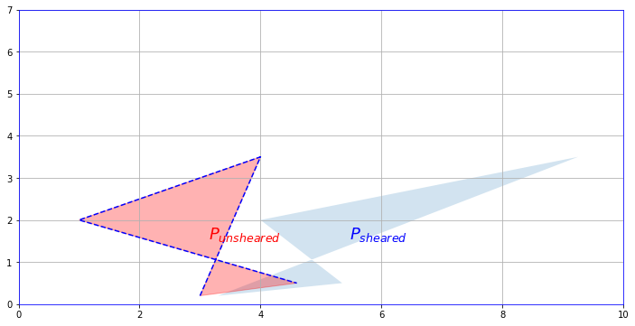

```python
F_inv_shear = np.array([
    [1, -1.5],
    [0, 1]
])
P_sheared = F_shear.dot(P)
P_unsheared = F_inv_shear.dot(P_sheared)
plot_transformation(P_sheared, P_unsheared, "$P_{sheared}$", "$P_{unsheared}$",
                    axis=[0, 10, 0, 7])
plt.plot(P[0], P[1], "b--");
```

```python
F_inv_shear = LA.inv(F_shear)
F_inv_shear
```

```
array([[ 1. , -1.5],
       [ 0. ,  1. ]])
```

Only square matrices can be inversed. This makes sense when you think about it: if you have a transformation that reduces the number of dimensions, then some information is lost and there is no way that you can get it back. For example say you use a $2 \times 3$ matrix to project a 3D object onto a plane. The result may look like this:

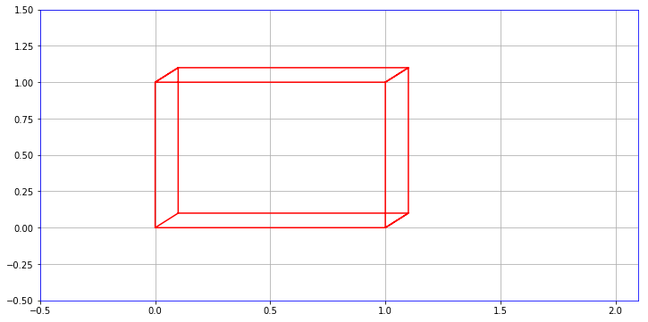

```python
plt.plot([0, 0, 1, 1, 0, 0.1, 0.1, 0, 0.1, 1.1, 1.0, 1.1, 1.1, 1.0, 1.1, 0.1],
         [0, 1, 1, 0, 0, 0.1, 1.1, 1.0, 1.1, 1.1, 1.0, 1.1, 0.1, 0, 0.1, 0.1],
         "r-")
plt.axis([-0.5, 2.1, -0.5, 1.5])
plt.grid()
```

Looking at this image, it is impossible to tell whether this is the projection of a cube or the projection of a narrow rectangular object. Some information has been lost in the projection.

Even square transformation matrices can lose information. For example, consider this transformation matrix:

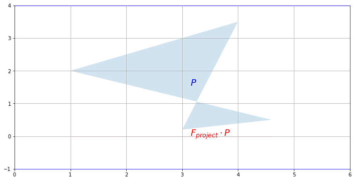

```python
F_project = np.array([
        [1, 0],
        [0, 0]
    ])
plot_transformation(P, F_project.dot(P), "$P$", "$F_{project} \cdot P$",
                    axis=[0, 6, -1, 4])
```

This transformation matrix performs a projection onto the horizontal axis. Our polygon gets entirely flattened out so some information is entirely lost and it is impossible to go back to the original polygon using a linear transformation. In other words, $F_{project}$ has no inverse. Such a square matrix that cannot be inversed is called a **singular matrix** (aka degenerate matrix). If we ask NumPy to calculate its inverse, it raises an exception:

```python
try:
    LA.inv(F_project)
except LA.LinAlgError as e:
    print("LinAlgError:", e)
```

```
LinAlgError: Singular matrix
```

Here is another example of a singular matrix. This one performs a projection onto the axis at a 30° angle above the horizontal axis:

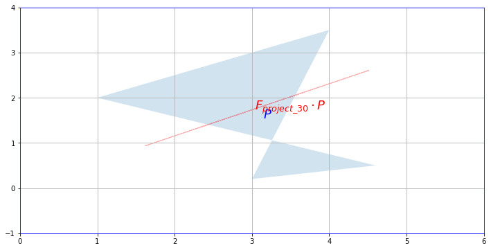

```python
angle30 = 30 * np.pi / 180
F_project_30 = np.array([
               [np.cos(angle30)**2, np.sin(2*angle30)/2],
               [np.sin(2*angle30)/2, np.sin(angle30)**2]
         ])
plot_transformation(P, F_project_30.dot(P), "$P$", "$F_{project\_30} \cdot P$",
                    axis=[0, 6, -1, 4])
```

```python
F_shear.dot(LA.inv(F_shear))
```

```
array([[ 1.,  0.],
       [ 0.,  1.]])
```

## Determinant

The determinant of a square matrix $M$, noted $\det(M)$ or $\det M$ or $|M|$ is a value that can be calculated from its elements $(M_{i,j})$ using various equivalent methods. One of the simplest methods is this recursive approach:

$|M| = M_{1,1}\times|M^{(1,1)}| - M_{2,1}\times|M^{(2,1)}| + M_{3,1}\times|M^{(3,1)}| - M_{4,1}\times|M^{(4,1)}| + \cdots ± M_{n,1}\times|M^{(n,1)}|$

- Where $M^{(i,j)}$ is the matrix $M$ without row $i$ and column $j$.

For example, let's calculate the determinant of the following $3 \times 3$ matrix:

$M = \begin{bmatrix} 1 & 2 & 3 \\ 4 & 5 & 6 \\ 7 & 8 & 0 \end{bmatrix}$

Using the method above, we get:

[output not shown]

Now we need to compute the determinant of each of these $2 \times 2$ matrices (these determinants are called **minors**):

$\left | \begin{bmatrix} 5 & 6 \\ 8 & 0 \end{bmatrix} \right | = 5 \times 0 - 6 \times 8 = -48$

$\left | \begin{bmatrix} 4 & 6 \\ 7 & 0 \end{bmatrix} \right | = 4 \times 0 - 6 \times 7 = -42$

$\left | \begin{bmatrix} 4 & 5 \\ 7 & 8 \end{bmatrix} \right | = 4 \times 8 - 5 \times 7 = -3$

Now we can calculate the final result:

```python
M = np.array([
        [1, 2, 3],
        [4, 5, 6],
        [7, 8, 0]
    ])
LA.det(M)
```

```
27.0
```

One of the main uses of the determinant is to *determine* whether a square matrix can be inversed or not: if the determinant is equal to 0, then the matrix *cannot* be inversed (it is a singular matrix), and if the determinant is not 0, then it *can* be inversed.

```python
LA.det(F_project_30)
```

```
1.6148781609251353e-17
```

```python
LA.det(F_shear)
```

```
1.0
```

The determinant can also be used to measure how much a linear transformation affects surface areas: for example, the projection matrices $F_{project}$ and $F_{project\_30}$ completely flatten the polygon $P$, until its area is zero. This is why the determinant of these matrices is 0. The shear mapping modified the shape of the polygon, but it did not affect its surface area, which is why the determinant is 1. You can try computing the determinant of a rotation matrix, and you should also find 1. What about a scaling matrix? Let's see:

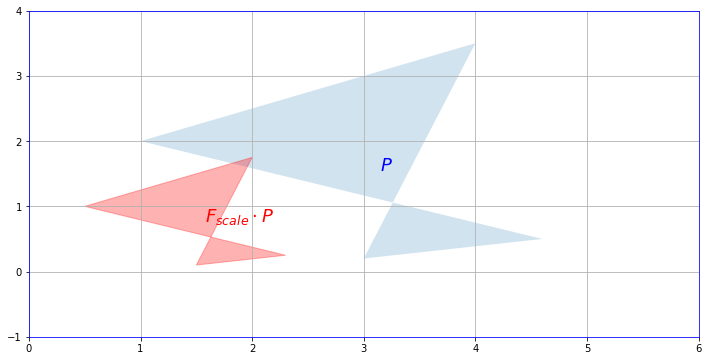

```python
F_scale = np.array([
        [0.5, 0],
        [0, 0.5]
    ])
plot_transformation(P, F_scale.dot(P), "$P$", "$F_{scale} \cdot P$",
                    axis=[0, 6, -1, 4])
```

We rescaled the polygon by a factor of 1/2 on both vertical and horizontal axes so the surface area of the resulting polygon is 1/4$^{th}$ of the original polygon. Let's compute the determinant and check that:

```python
LA.det(F_scale)
```

```
0.25
```

```python
LA.det(F_reflect)
```

```
-1.0
```

```python
P_squeezed_then_sheared = F_shear.dot(F_squeeze.dot(P))
P_squeezed_then_sheared
```

```
array([[ 4.41428571,  9.35      ,  3.54285714,  6.97571429],
       [ 0.14285714,  2.5       ,  1.42857143,  0.35714286]])
```

```python
P_squeezed_then_sheared = (F_shear.dot(F_squeeze)).dot(P)  #Associative property
```

```python
F_squeeze_then_shear = F_shear.dot(F_squeeze)
P_squeezed_then_sheared = F_squeeze_then_shear.dot(P)
```

What if you want to perform the inverse of this double transformation? Well, if you squeezed and then you sheared, and you want to undo what you have done, it should be obvious that you should unshear first and then unsqueeze. In more mathematical terms, given two invertible (aka nonsingular) matrices $Q$ and $R$:

$(Q \cdot R)^{-1} = R^{-1} \cdot Q^{-1}$

And in NumPy:

```python
LA.inv(F_shear.dot(F_squeeze)) == LA.inv(F_squeeze).dot(LA.inv(F_shear))
```

```
array([[ True,  True],
       [ True,  True]], dtype=bool)
```

## Singular Value Decomposition

It turns out that any $m \times n$ matrix $M$ can be decomposed into the dot product of three simple matrices:

- a rotation matrix $U$ (an $m \times m$ orthogonal matrix)
- a scaling & projecting matrix $\Sigma$ (an $m \times n$ diagonal matrix)
- and another rotation matrix $V^T$ (an $n \times n$ orthogonal matrix)

$M = U \cdot \Sigma \cdot V^{T}$

For example, let's decompose the shear transformation:

```python
U, S_diag, V_T = LA.svd(F_shear)
U
```

```
array([[ 0.89442719, -0.4472136 ],
       [ 0.4472136 ,  0.89442719]])
```

```python
S_diag
```

```
array([ 2. ,  0.5])
```

```python
V_T
```

```
array([[ 0.4472136 ,  0.89442719],
       [-0.89442719,  0.4472136 ]])
```

Note that this is just a 1D array containing the diagonal values of Σ. To get the actual matrix Σ, we can use NumPy's `diag` function:

```python
S = np.diag(S_diag)
S
```

```
array([[ 2. ,  0. ],
       [ 0. ,  0.5]])
```

```python
U.dot(np.diag(S_diag)).dot(V_T)
```

```
array([[  1.00000000e+00,   1.50000000e+00],
       [ -1.25949234e-17,   1.00000000e+00]])
```

```python
F_shear
```

```
array([[ 1. ,  1.5],
       [ 0. ,  1. ]])
```

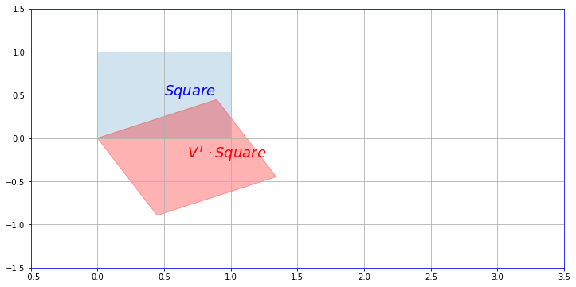

```python
plot_transformation(Square, V_T.dot(Square), "$Square$", "$V^T \cdot Square$",
                    axis=[-0.5, 3.5 , -1.5, 1.5])
```

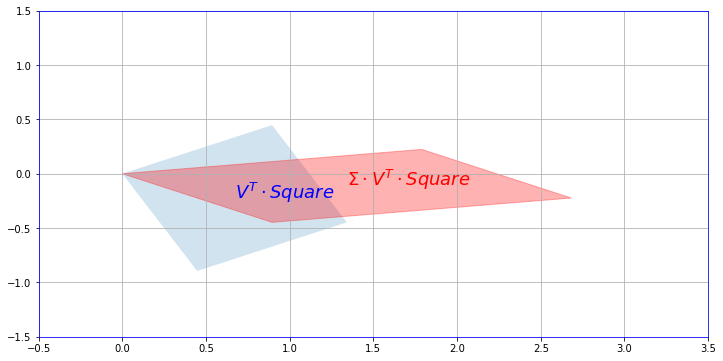

```python
plot_transformation(V_T.dot(Square), S.dot(V_T).dot(Square), "$V^T \cdot Square$", "$\Sigma \cdot V^T \cdot Square$",
                    axis=[-0.5, 3.5 , -1.5, 1.5])
```

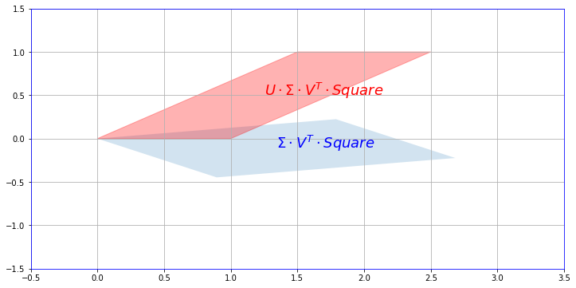

```python
plot_transformation(S.dot(V_T).dot(Square), U.dot(S).dot(V_T).dot(Square),"$\Sigma \cdot V^T \cdot Square$", "$U \cdot \Sigma \cdot V^T \cdot Square$",
                    axis=[-0.5, 3.5 , -1.5, 1.5])
```

And we can see that the result is indeed a shear mapping of the original unit square.

```python
#Spouse = np.array([[7,8,6,7,7,4,7], [8, 6, 9, 4, 7, 7, 7],[4, 8, 9, 7, 6, 7, 7],[9, 6, 5, 5, 7, 6, 6]] )
```

```python
#weights = np.array([0.6, 0.8, 0.9, 0.7, 0.6, 0.8, 0.8])
```

```python
#Spouse
```

```python
#weights
```

```python
#Spouse.dot(weights)
```